# Assignment 1 - The tidyverse

GIORGIO COPPOLA (giocopp) - 224545

September 25, 2023 | 19:10:04 | CEST

```r
# LOAD THE PACKAGES YOU ARE USING IN THIS CODE CHUNK library(nameofpackage)
library(legislatoR)
library(dplyr)
library(ggplot2)
library(ggrepel)
library(viridis)
```

### Getting started with the Comparative Legislators Database

The Comparative Legislators Database (CLD) includes political, sociodemographic, career, online presence, public attention, and visual information for over 45,000 contemporary and historical politicians from ten countries (see the [corresponding article](https://www.cambridge.org/core/journals/british-journal-of-political-science/article/comparative-legislators-database/D28BB58A8B2C08C8593DB741F42C18B2) for more information). It can be accessed via `legislatoR` - an R package that is available on both [CRAN](https://cran.r-project.org/web/packages/legislatoR/index.html) and [GitHub](https://github.com/saschagobel/legislatoR).

Before you start with the following tasks, skim the tutorial to make yourself familiar with the database. You find it [here](https://cran.r-project.org/web/packages/legislatoR/vignettes/legislatoR.html).

For the following tasks, you will work with ONE of the legislatures. The legislature you’ll work with depends on your first name:

| Your first name starts with… | Legislature | Code |
| --- | --- | --- |
| A-C | Austrian Nationalrat | `aut` |
| D-F | Canadian House of Commons | `can` |
| G-I | Czech Poslanecka Snemovna | `cze` |
| J-L | Spanish Congreso de los Diputados | `esp` |
| M-O | French Assemblée | `fra` |
| P-R | German Bundestag | `deu` |
| S-U | Irish Dail | `irl` |
| V-X | UK House of Commons | `gbr` |
| Y-Z | US House of Representatives | `usa_house` |

The following tasks will be based on data from the `core` and `political` tables of the database.

### Task 1 - Descriptives [8 points in total]

1. What’s the overall share of female legislators in the entire dataset?

```r
# YOUR CODE HERE
# we will use the core data (sociodemographics) for this part of the analysis
core_cze <- get_core("cze")

# check for NAs
# sum(is.na(core_cze$sex))

# share of male legislators
T1a <- core_cze %>%
  filter(!is.na(sex == "female")) %>%
  summarise(percentage_female = sum(sex == "female") / n() * 100) %>%
  pull(percentage_female)

round(T1a, 2)
```

```
[1] 19.5
```

2. How many (both in absolute and relative terms) legislators died in the same place they were born in? [1 point]

```r
# YOUR CODE HERE
T1b_1 <- core_cze %>%
  filter(!is.na(birthplace) & !is.na(deathplace)) %>% # among those for which data on birthplace and deathplace is available
  summarise(
    absolute_counts = sum(birthplace == deathplace),
    relative_percentage = (sum(birthplace == deathplace) / n()) * 100
  )

T1b_1
```

| absolute_counts | relative_percentage |
| --- | --- |
| 6 | 40 |

```r
T1b_2 <- core_cze %>%
  filter(!is.na(death)) %>% # among those who  died
  summarise(
    absolute_counts = sum(birthplace == deathplace, na.rm = TRUE),
    relative_percentage = (sum(birthplace == deathplace, na.rm = TRUE) / n()) * 100
  )

T1b_2
```

| absolute_counts | relative_percentage |
| --- | --- |
| 6 | 12.5 |

3. Create a new variable `age_at_death` that reports the age at which legislators died. Then, plot the distribution of that variable for the entire dataset. [2 points]

```r
# YOUR CODE HERE
# creating the new variable
T1c <- core_cze %>%
  filter(!is.na(birth) & !is.na(death)) %>%
  mutate(age_at_death = round(as.numeric(difftime(death, birth, units = "days")) / 365))

T1c
```

| country | pageid | wikidataid | wikititle | name | sex | ethnicity | religion | birth | death | birthplace | deathplace | age_at_death |
| --- | --- | --- | --- | --- | --- | --- | --- | --- | --- | --- | --- | --- |
| CZE | 846261 | Q10820050 | Andrej_Gjurič | Andrej Gjurič | male | NA | NA | 1938-11-29 | 2015-09-27 | 50.08861,14.42139 | 49.57687,14.07187 | 77 |
| CZE | 814161 | Q10854110 | Antonín_Sochor_(matematik) | Antonín Sochor | male | NA | NA | 1942-03-01 | 2008-05-17 | NA | NA | 66 |
| CZE | 286421 | Q264133 | Augustin_Bubník | Augustin Bubník | male | white | NA | 1928-11-21 | 2017-04-18 | 50.08861,14.42139 | 50.08861,14.42139 | 88 |
| CZE | 868513 | Q11874384 | Eduard_Vávra | Eduard Vávra | male | NA | NA | 1943-08-02 | 2017-03-20 | NA | NA | 74 |
| CZE | 111966 | Q11874424 | Eduard_Zeman | Eduard Zeman | male | NA | NA | 1948-04-11 | 2017-06-25 | 50.50306,13.63667 | NA | 69 |
| CZE | 861703 | Q9263360 | František_Chobot | František Chobot | male | NA | NA | 1939-02-19 | 2013-08-20 | 50.08861,14.42139 | NA | 75 |
| CZE | 868533 | Q12017586 | František_Vnouček_(politik) | František Vnouček | male | NA | NA | 1945-11-16 | 2008-05-22 | 49.82972,14.69057 | NA | 63 |
| CZE | 335896 | Q12018978 | Hana_Orgoníková | Hana Orgoníková | female | white | NA | 1946-12-08 | 2014-06-05 | 49.57689,15.73859 | 50.20917,15.83194 | 68 |
| CZE | 863894 | Q12023564 | Jarmila_Boháčková | Jarmila Boháčková | female | NA | NA | 1947-07-18 | 2005-06-09 | 50.08861,14.42139 | NA | 58 |
| CZE | 862536 | Q12023943 | Jaroslav_Maňásek | Jaroslav Maňásek | male | NA | NA | 1943-04-06 | 2006-06-29 | NA | 50.4125,14.90639 | 63 |

[output cut: 38 more lines]

```r
# playing around
```

```
#> T1c %>%
#> summarise(youngest = min(age_at_death, na.rm = T), .by = c(sex))
```

```
#> T1c %>%
#> summarise(oldest = max(age_at_death, na.rm = T), .by = c(sex))
```

```
#> T1c %>%
#> arrange(desc(age_at_death)) %>%
#> select(name, age_at_death, sex)
```

```
#> T1c %>%
#> arrange(age_at_death) %>%
#> group_by(sex) %>%
#> slice_head(n = 5) %>%
#> select(name, age_at_death, sex)
```

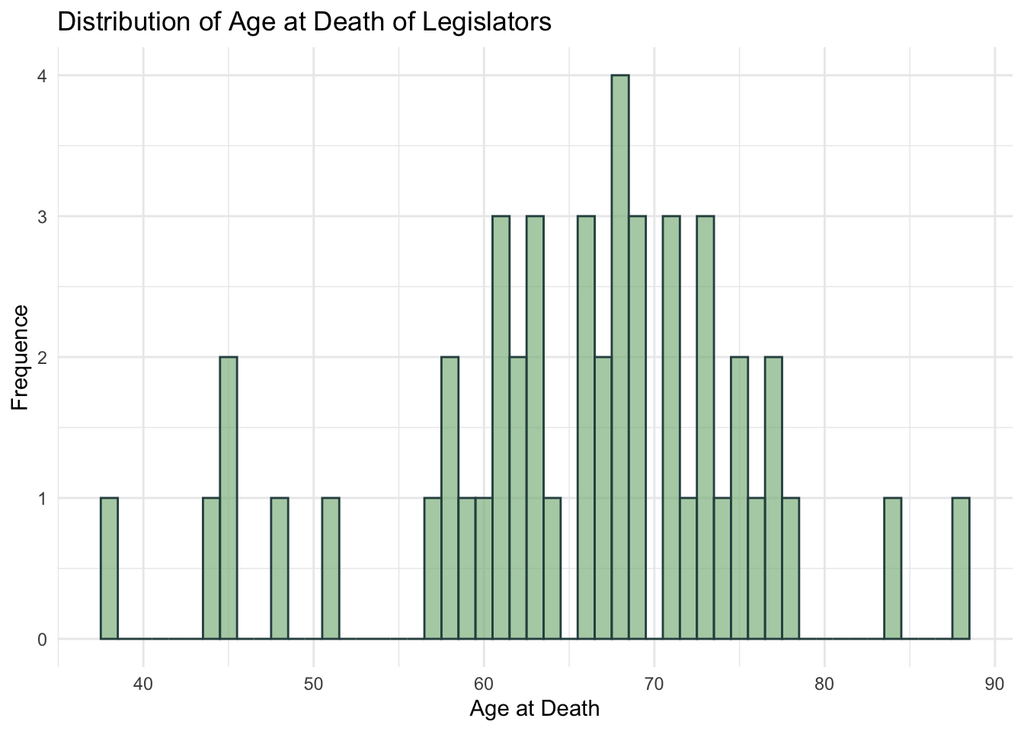

```r
# plotting distribution
T1c_plot <- ggplot(T1c, aes(x = age_at_death)) +
  geom_histogram(binwidth = 1, fill = "darkseagreen", color = "darkslategray", alpha = 0.7) +
  labs(title = "Distribution of Age at Death of Legislators",
       x = "Age at Death",
       y = "Frequence") +
  theme_minimal()

T1c_plot
```

4. What is the most frequent birthday in your sample (e.g., “January 15”)? [2 points]

```r
# YOUR CODE HERE
T1d <- core_cze %>%
  mutate(birthday = format(birth, "%m-%d")) %>% # adding a variable in the df, taking data from the "birth" variable, using only day and month. The format function is useful to extract and format the date.
  count(birthday) %>%
  top_n(1, wt = n) # top_n function suggested by ChatGPT. An alternative would be arrange(desc(n)) %>%  slice(1), but top_n is more concise.

T1d
```

| birthday | n |
| --- | --- |
| 01-01 | 13 |

The most frequent birthday (date regardless the year) is January the 1st, with 13 counts. This is probably because of some issues with data collection. It is plausible that the 1st of January has been used as placeholder for whose legislators lacking of their day and month of birth.

5. Generate a table that provides the 5 legislators with the longest names (in terms of number of characters, ignoring whitespace). [2 points]

```r
# YOUR CODE HERE
T1e <- core_cze %>%
  mutate(name_length = nchar(gsub(" ", "", name))) %>% # gsub function suggested by ChatGPT. It replaces all spaces " " with an empty string "", removing all spaces from the "name" columns..
  arrange(desc(name_length)) %>%
  slice_head(n = 5) %>%
  select(name, name_length)

T1e
```

| name | name_length |
| --- | --- |
| Zuzana Majerová Zahradníková | 26 |
| Jaroslava Pokorná Jermanová | 25 |
| Augustin Karel Andrle Sylor | 24 |
| Jana Mračková Vildumetzová | 24 |
| Zdenka Němečková Crkvenjaš | 24 |

### Task 2 - Exploring trends in the data [8 points in total]

1. Using data from all sessions, provide a plot that shows the share of female legislators by session! [3 points]

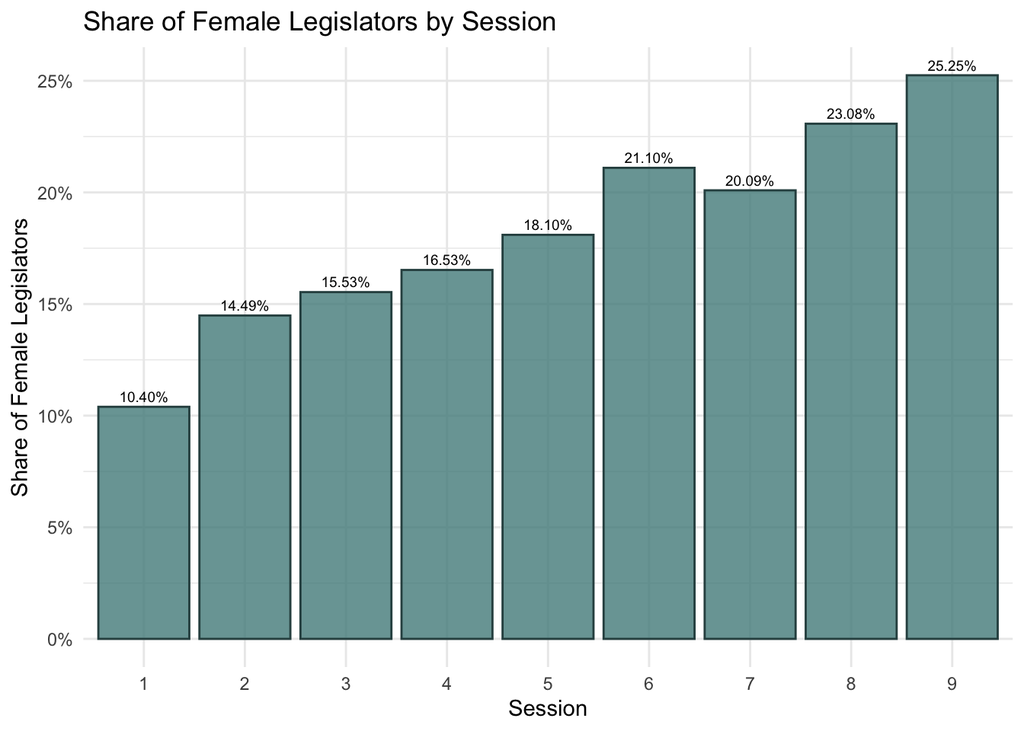

```r
# YOUR CODE HERE
#  joining the datasets
political_cze <-  get_political("cze")
joint_cze <- left_join(x = get_core(legislature = "cze"),
                      y = get_political(legislature = "cze"),
                      by = "pageid")

# creating the dataset grouped by session
T2a <- joint_cze %>%
  group_by(session) %>%
  summarize(
    total_legislators = n(),
    female_legislators = sum(sex == "female", na.rm = TRUE),
    female_share = female_legislators / total_legislators
  )

# plotting distributions
T2a_plot <- T2a %>%
  ggplot(aes(x = session, y = female_share)) +
  geom_col(fill = "darkslategray4", color = "darkslategrey", alpha = 0.8) +
  geom_text(aes(label = scales::percent(female_share)), vjust = -0.5, size = 2.5) +
  labs(title = "Share of Female Legislators by Session",
       x = "Session",
       y = "Share of Female Legislators") +
  scale_y_continuous(labels = scales::percent) +
  scale_x_discrete(limits = as.character(1:9)) +
  theme_minimal()

T2a_plot
```

2. Explore another relation of variables in the dataset. Your analysis should (i) use data from both the `core` and the `political` table and (ii) feature data from several sessions. Also, offer a brief description and interpretation of your findings! [5 points]

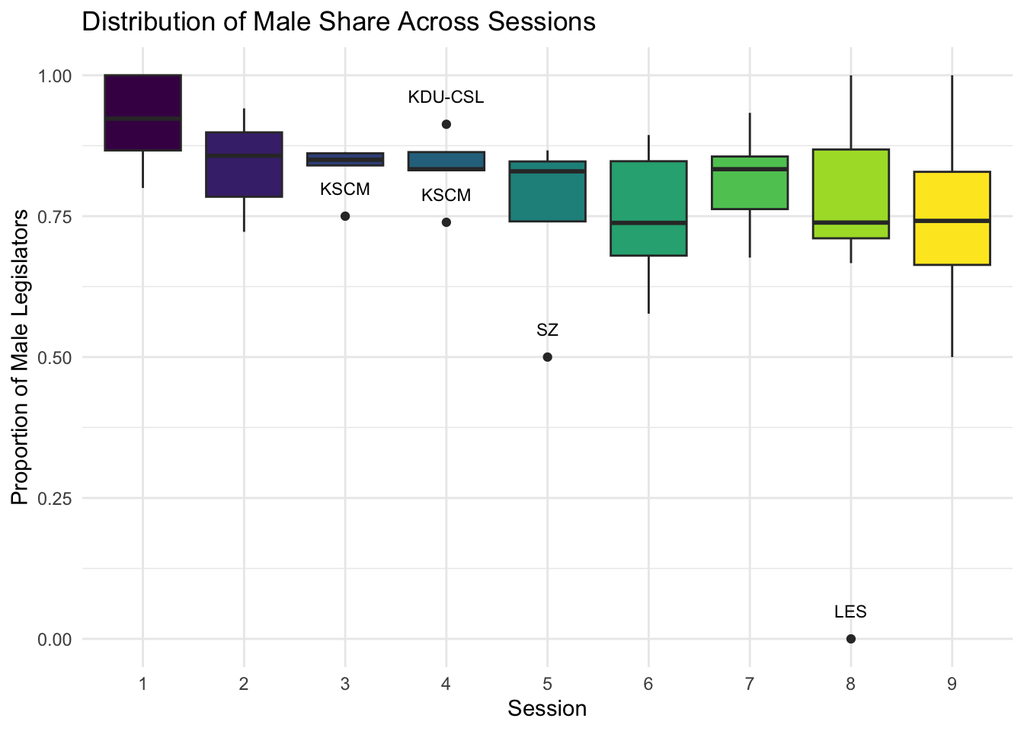

```r
# YOUR CODE HERE´
# Gender (im)balance across parties and session in Cze
T2b <- joint_cze %>%
  group_by(session, party) %>%
  summarize(
    total_legislators = n(),
    male_legislators = sum(sex == "male", na.rm = TRUE),
    male_share = male_legislators / total_legislators
  )

# plots:  boxplot and  line graphs.
# boxplot of male share distribution per session
session_bounds <- T2b %>%
  group_by(session) %>%
  summarise(
    lower_bound = quantile(male_share, 0.25) - 1.5 * IQR(male_share),
    upper_bound = quantile(male_share, 0.75) + 1.5 * IQR(male_share)
  )

T2b_with_bounds <- T2b %>% # useful for better visualization
  left_join(session_bounds, by = "session")

T2b_boxplot_session <-  T2b_with_bounds %>%
  ggplot(aes(x = as.factor(session), y = male_share, fill = as.factor(session))) +
    geom_boxplot() +
    geom_text(data = subset(T2b_with_bounds, male_share > upper_bound | male_share < lower_bound), # adding names to outliers (asked to ChatGPT)
              aes(label = party), nudge_y = 0.05, check_overlap = TRUE, size = 3) +
    scale_fill_viridis(discrete = TRUE, option = "viridis") +
    labs(
      title = "Distribution of Male Share Across Sessions",
      x = "Session",
      y = "Proportion of Male Legislators"
    ) +
    theme_minimal() +
    theme(legend.position = "none")

T2b_boxplot_session
```

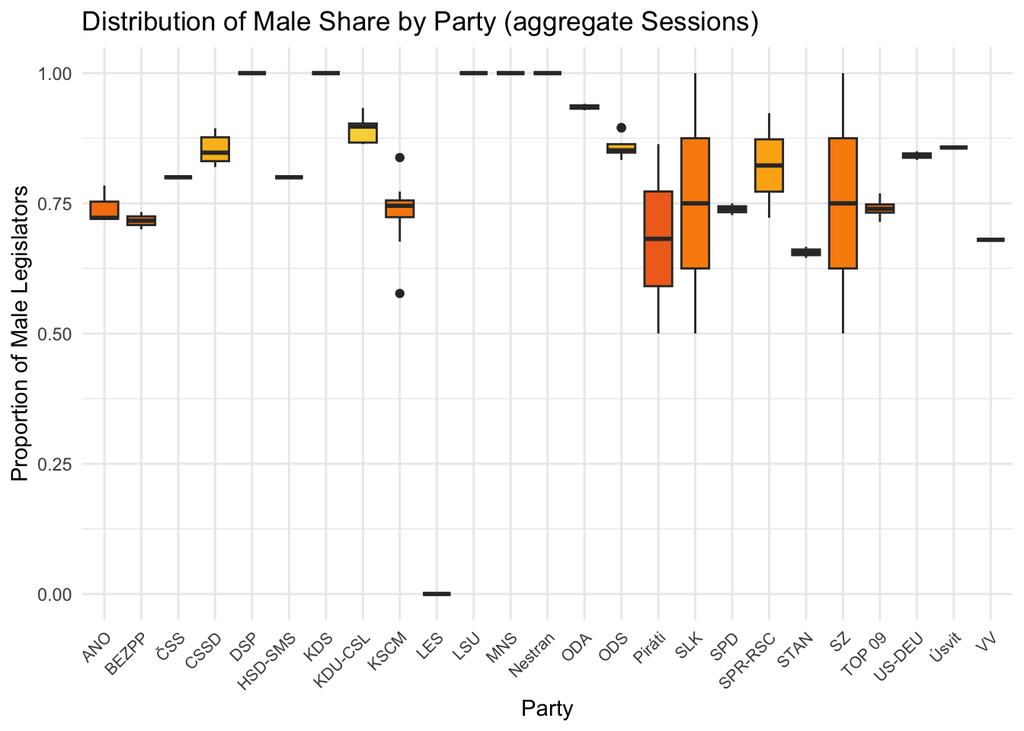

```r
# boxplot of male share distribution per party
party_medians <- T2b %>%
  group_by(party) %>%
  summarize(median_male_share = median(male_share, na.rm = TRUE)) # will use for visualization

T2b_boxplot_party <- T2b %>%
  left_join(party_medians, by = "party") %>% # visualization tricks suggested by ChatGPT, used for coloring
  ggplot(aes(x = party, y = male_share, fill = median_male_share)) +
    geom_boxplot() +
    scale_fill_viridis(option = "inferno") +
    labs(
      title = "Distribution of Male Share by Party (aggregate Sessions)",
      x = "Party",
      y = "Proportion of Male Legislators"
    ) +
    theme_minimal() +
    theme(axis.text.x = element_text(angle = 45, hjust = 1, vjust = 1, size = 8)) +
    theme(legend.position = "none")

T2b_boxplot_party
```

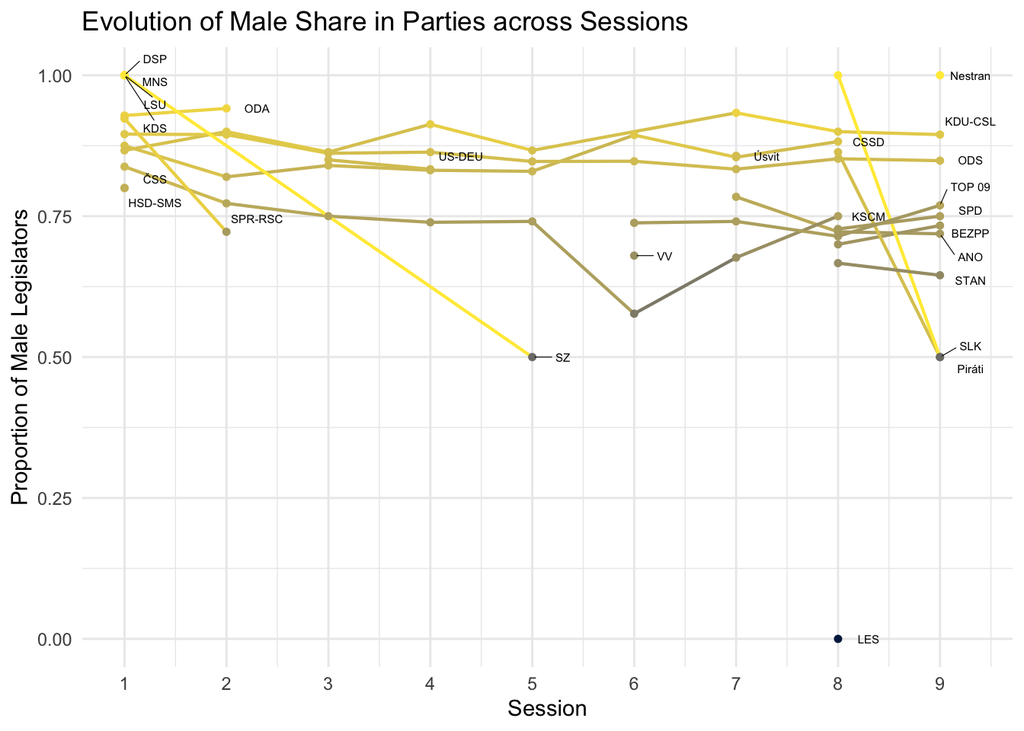

```r
# line graph
label_data <- T2b %>%
  group_by(party) %>%
  arrange(session) %>%
  slice_tail(n = 1)

T2b_graph <- T2b %>%
  ggplot(aes(x = as.numeric(session), y = male_share, group = party)) +
    geom_line(aes(color = male_share), size = 0.75) +
    geom_point(aes(color = male_share), size = 1.25) +
    geom_text_repel(data = label_data, # suggested by ChatGPT
                aes(label = party),
                nudge_x = 0.3,
                direction = "y",
                segment.size = 0.2,
                size = 2) +
    scale_x_continuous(breaks = 1:9, labels = 1:9) +
    scale_color_viridis(option = "cividis") +
    labs(
      title = "Evolution of Male Share in Parties across Sessions",
      x = "Session",
      y = "Proportion of Male Legislators",
      color = "Party"
    ) +
    theme_minimal() +
    theme(legend.position = "none")

T2b_graph
```

These three graphs show the distribution of gender imbalance in political parties in the Czech Republic over different sessions and per party.

From ‘T2b_boxplot_session’ we can see the general development of the gender balance between sessions, aggregating all the parties together. We can see a slight increase in gender balance, but we cannot see how these distributions change within the different parties. This plot gives a bit more information than the ‘T2a_plot’, as we can now observe the variance of the data across different sessions, as well as any outliers. The colours are used here for aesthetic reasons only.

The ‘T2b_boxplot_party’ gives information about the gender balance in different parties by aggregating sessions. Therefore, we cannot observe the directon of the change of gender balance over time, but we can observe gender imbalances within parties, and therefore, assess the variance of gender composition of representatives, suggesting which party has changed its composition the most. The lighter the colour of the boxplot represents a stronger domination of men within the party, on average over all sessions. We can approximate this data by saying that the darker the colour, the more balanced the party composition is in terms of gender. We can identify SZ, Piráti and SLK as the parties that have the highest variance in the data, and therefore that changed the most the composition of their representatives in terms of gender. A notable outlier is LES, which had only female representatives in the eighth session.

The last graph (‘T2b_graph’) shows the evolution of the gender balance in each party over time (in different sessions). Again, a darker colour is associated with a greater presence of women in the party. From this graph we can see the improvements that some parties have made, but in general there is still massive progress to be made. We can see that some parties have significantly balanced their composition. This graph is really informative as a supplement of the previous one (‘T2b_boxplot_party’), as now we can track the evolution of gender balance of parties through time (sessions). We see that SZ had only male representatives in the first session and achieved full gender balance (50%) in the fifth session. Similarly, Piráti and SLK achieved the same result in only one session. Despite some improvements, from this descriptive graphs we can conclude that political parties in the Czech Republic are still predominantly composed by male representatives.

Notice: all the codes suggested by ChatGPT have been remodeled and adapted, checking on StackOverflow if necessary.